# Stage 2: Stints, Segments, and Identification

Results come from the pipeline (`targets::tar_make()` in the project root); this report only reads and displays them. A stint is a stretch of play with the same players on the pitch; a segment is a stint split further at goals and 15-minute clock edges. The identification diagnostics use the shot-volume model; volume, xG, and big chances share the same design, so collinearity is identical across them.

```r
library(targets)
library(dplyr)
library(ggplot2)
tar_source()
```

```r
stints <- tar_read(stints)
stint_table <- tar_read(stint_table)
segment_table <- tar_read(segment_table)
player_mins <- tar_read(player_mins)
overlap <- tar_read(overlap)
```

## 1. Stints

Building the stint and segment tables checks that every open-play shot is counted once and that both reproduce the stage 1 team-match table exactly.

```r
show_table(stint_overview(stints, stint_table))
```

| Quantity | Value |
| --- | --- |
| Stints | 11,579 |
| Stints per match (mean / min / max) | 7.6 / 4 / 11 |
| Stint length in minutes (median / 10th / 90th percentile) | 8.0 / 1.2 / 43.1 |
| Share of minutes at 11 v 11 | 92.4% |
| Distinct players appearing | 2,176 |

```r
show_table(stint_table |>
  group_by(league) |>
  summarise(stint_rows = n(),
            median_minutes = round(median(minutes), 1),
            shots_per_90 = round(90 * sum(n_shots) / sum(minutes), 2),
            xg_per_90 = round(90 * sum(xg) / sum(minutes), 3),
            big_chances_per_90 = round(90 * sum(big_chances) / sum(minutes), 3),
            .groups = "drop"))
```

| league | stint_rows | median_minutes | shots_per_90 | xg_per_90 | big_chances_per_90 |
| --- | --- | --- | --- | --- | --- |
| La Liga | 5812 | 7.9 | 10.90 | 1.116 | 1.337 |
| Ligue 1 | 5846 | 7.5 | 10.39 | 0.990 | 1.145 |
| Premier League | 5494 | 8.6 | 11.56 | 1.085 | 1.183 |
| Serie A | 6006 | 7.9 | 11.68 | 1.002 | 1.091 |

## 2. Segments

```r
cat(sprintf("Segments: %d\n", nrow(tar_read(segments))))
```

```
## Segments: 21644
```

```r
show_table(segment_table |>
  group_by(time_bin) |>
  summarise(segment_rows = n(), minutes = round(sum(minutes)),
            shots_per_90 = round(90 * sum(n_shots) / sum(minutes), 2), .groups = "drop"))
```

| time_bin | segment_rows | minutes | shots_per_90 |
| --- | --- | --- | --- |
| P1 0-15 | 4224 | 45510 | 9.49 |
| P1 15-30 | 4500 | 45510 | 10.72 |
| P1 30-45+ | 4874 | 49559 | 10.94 |
| P2 0-15 | 6598 | 45510 | 11.63 |
| P2 15-30 | 11240 | 45510 | 11.60 |
| P2 30-45+ | 11852 | 57137 | 12.19 |

## 3. How minutes are distributed

```r
show_table(minutes_table(player_mins))
```

| Minutes threshold | Players | Share of player-minutes | Players on more than one team |
| --- | --- | --- | --- |
| All players | 2176 | 100.0% | 103 |
| >= 300 | 1779 | 98.6% | 95 |
| >= 900 | 1368 | 91.0% | 77 |
| >= 1800 | 842 | 68.9% | 31 |

Goalkeepers get defensive effects but no offensive ones.

```r
show_table(goalkeeper_table(stint_table, player_mins))
```

| Quantity | Value |
| --- | --- |
| Goalkeepers appearing | 183 |
| Goalkeepers with >= 900 minutes | 100 |
| Median share of team minutes (those goalkeepers) | 81.6% |
| Goalkeepers playing more than 90% of team minutes | 32 |

## 4. Teammate overlap

Outfield players with at least 900 minutes. Overlap is the share of the lower-minute player’s time spent on the pitch with the other.

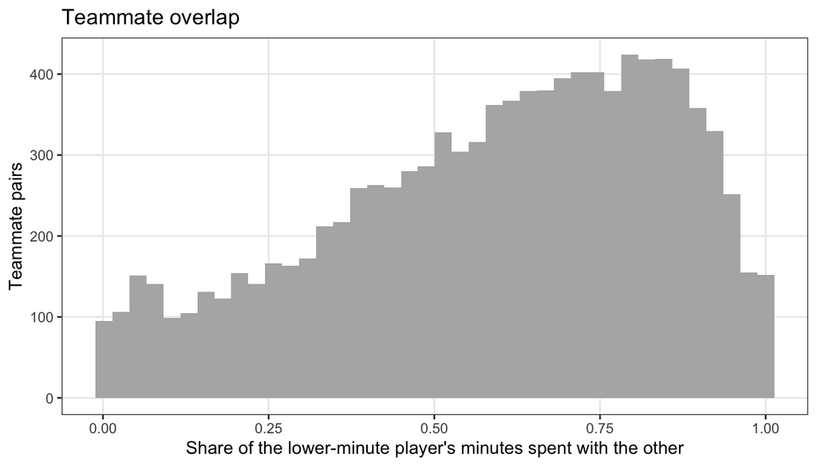

```r
plot_overlap(overlap)
```

```r
show_table(overlap_summary(overlap))
```

| Quantity | Value |
| --- | --- |
| Teammate pairs sharing any minutes | 10,453 |
| Pairs with overlap above 0.90 | 1,016 (9.7%) |
| Pairs with overlap above 0.95 | 402 (3.8%) |
| Median overlap | 0.63 |

```r
show_table(top_overlap_pairs(overlap, player_mins))
```

| Team | Player 1 | Player 2 | Shared minutes | Overlap |
| --- | --- | --- | --- | --- |
| AFC Bournemouth | Andrew Surman | Simon Francis | 3633 | 1 |
| AFC Bournemouth | Andrew Surman | Charlie Daniels | 3521 | 1 |
| Stade Malherbe Caen | Julien Féret | Dennis Appiah | 3426 | 1 |
| AFC Bournemouth | Steve Cook | Andrew Surman | 3425 | 1 |
| Leicester City | Wes Morgan | Robert Huth | 3383 | 1 |
| Leicester City | Wes Morgan | Jamie Vardy | 3340 | 1 |
| Stade Malherbe Caen | Andy Delort | Dennis Appiah | 3287 | 1 |
| Leicester City | Wes Morgan | N’Golo Kanté | 3241 | 1 |
| Leicester City | Danny Drinkwater | Wes Morgan | 3230 | 1 |
| AFC Bournemouth | Matt Ritchie | Andrew Surman | 3176 | 1 |

## 5. Design conditioning and precision

Standard errors a Poisson shot-volume model could achieve without shrinkage, as a percentage change in shots per 90, against the spread of team attack effects.

```r
show_table(precision_table(tar_read(precision)))
```

| Quantity | Value |
| --- | --- |
| Player effects (offense / defense) | 1268 / 1368 |
| Aliased player columns (never apart from others) | 2 (def_3815, def_22111) |
| Condition number, player design (aliased columns removed) | 4.1e+05 |
| Player effect SE, median (% shots per 90) | 19.1 |
| Player effect SE, 90th percentile (% shots per 90) | 28.6 |
| Team effect SE, median (% shots per 90) | 6.9 |
| Spread of team attack effects, SD (% shots per 90) | 14.6 |

## 6. Shrinkage and threshold choice

Effective df is the number of player parameters the data can support at each prior SD; where the posterior SD is close to the prior SD, the data adds little.

```r
show_table(tar_read(ridge))
```

| Prior SD (% shots per 90) | Player parameters | Effective df | Median posterior SD (%) | Share with posterior SD > 90% of prior |
| --- | --- | --- | --- | --- |
| 2.0 | 2636 | 166 | 2.0 | 100.0% |
| 5.1 | 2636 | 538 | 4.6 | 28.5% |
| 10.5 | 2636 | 1,093 | 7.9 | 0.8% |
| 22.1 | 2636 | 1,748 | 11.9 | 0.2% |
| 64.9 | 2636 | 2,351 | 16.2 | 0.0% |

```r
show_table(tar_read(thresholds))
```

| Threshold (minutes) | Offense / defense effects | Aliased player columns | Condition number | Median SE (%) | 90th pct SE (%) |
| --- | --- | --- | --- | --- | --- |
| 300 | 1643 / 1779 | 2 | 3.3e+06 | 25.1 | 42.3 |
| 900 | 1268 / 1368 | 2 | 4.1e+05 | 19.1 | 28.6 |
| 1800 | 765 / 842 | 2 | 1.2e+06 | 15.3 | 21.8 |